# Project2_McCants

Taylor McCants

16/5/2021

## Setup

```r
# load the packages
library(tidyverse)
library(lme4)
library(ggplot2)
library(broom.mixed)
library(lmerTest)
library(plyr)
library(lsm)
library(car)
library(stringr)
additional_packages <- c("multcomp", "PearsonDS", "ARTool", "qqplotr", "psych", "moments")
install.packages(setdiff(additional_packages, rownames(installed.packages())))
import::from(moments, skewness)
import::from(MASS,mvrnorm)
import::from(broom.mixed,tidy)
import::from(multcomp, glht, mcp, adjusted)
import::from(PearsonDS, rpearson)
import::from(ARTool, art, artlm, art.con)
import::from(qqplotr, stat_qq_line, stat_qq_point, stat_qq_band)
import::from(psych, d.ci)
import::from(cowplot, plot_grid)
import::from(modelr, add_residuals, add_predictions)
import::from(car, leveneTest, sigmaHat)
```

## Data Processing

Read the data files.

```r
# Regular expression to help parse the log files
regex_parse <- "User(\\d+)_T(\\d+)_(.*).csv"

# helper function to read in log files
read_log_files <- function(fileName){
  csv_data <- read_csv(str_c('./log/',fileName)) %>%
      mutate(length = str_length(stimulus)) %>%
      group_by(stimulus_index) %>%
      summarise(wpm = (as.double(max(length)-1)/5)/ as.double(max(input_time_ms)) * 60000, length = max(length)) %>%
      mutate(user_id = as.numeric(str_replace(fileName, regex_parse, "\\1")), condition = str_replace(fileName, regex_parse, "\\3"))
    return(csv_data)
}
# list of all log files
log_files <- list.files('./log')

# file that includes the participant information
participant_info <- read_csv("participant_info.csv")

# backup file that is already processed
combined_log_background <- read_csv(("combined_log_background.csv"))

# data wrangling
data <- as_tibble_col(lapply(log_files, read_log_files), col='nested') %>%
        unnest(nested) %>% merge(y=participant_info, by='user_id', all.x = TRUE ) %>%
        mutate(typing_style = if_else(is_touchtypist, 'Non-touchtypist', 'Touchtypist')) %>%
        select(-is_touchtypist, -length)

# ? TODO add comment
data_with_cond <- data %>% mutate(condition = factor(condition, levels = c("Sentences", "Mix", "Random")), typing_style = factor(typing_style, levels = c("Non-touchtypist", "Touchtypist")))
```

## Data Exploration and Description

Overview of data:

```
##   user_id      wpm condition    typing_style
## 1    5307 72.46826 Sentences Non-touchtypist
## 2    5307 64.70295       Mix Non-touchtypist
## 3    5307 16.96913    Random Non-touchtypist
## 4   68349 11.95815    Random     Touchtypist
## 5   68349 34.31902       Mix     Touchtypist
## 6   68349 46.01317 Sentences     Touchtypist
```

```
## 'data.frame':    90 obs. of  4 variables:
##  $ user_id     : num  5307 5307 5307 68349 68349 ...
##  $ wpm         : num  72.5 64.7 17 12 34.3 ...
##  $ condition   : chr  "Sentences" "Mix" "Random" "Random" ...
##  $ typing_style: chr  "Non-touchtypist" "Non-touchtypist" "Non-touchtypist" "Touchtypist" ...
```

### Visualize Descriptive Statisctics

Summary of the data

```
##     user_id            wpm          condition         typing_style
##  Min.   :  5307   Min.   : 7.257   Length:90          Length:90
##  1st Qu.:221357   1st Qu.:16.877   Class :character   Class :character
##  Median :374661   Median :34.693   Mode  :character   Mode  :character
##  Mean   :399680   Mean   :35.065
##  3rd Qu.:535385   3rd Qu.:49.085
##  Max.   :934313   Max.   :78.256
```

Violin plot that includes boxplots for *words per minute (wpm)* by the *typing styles* of users.

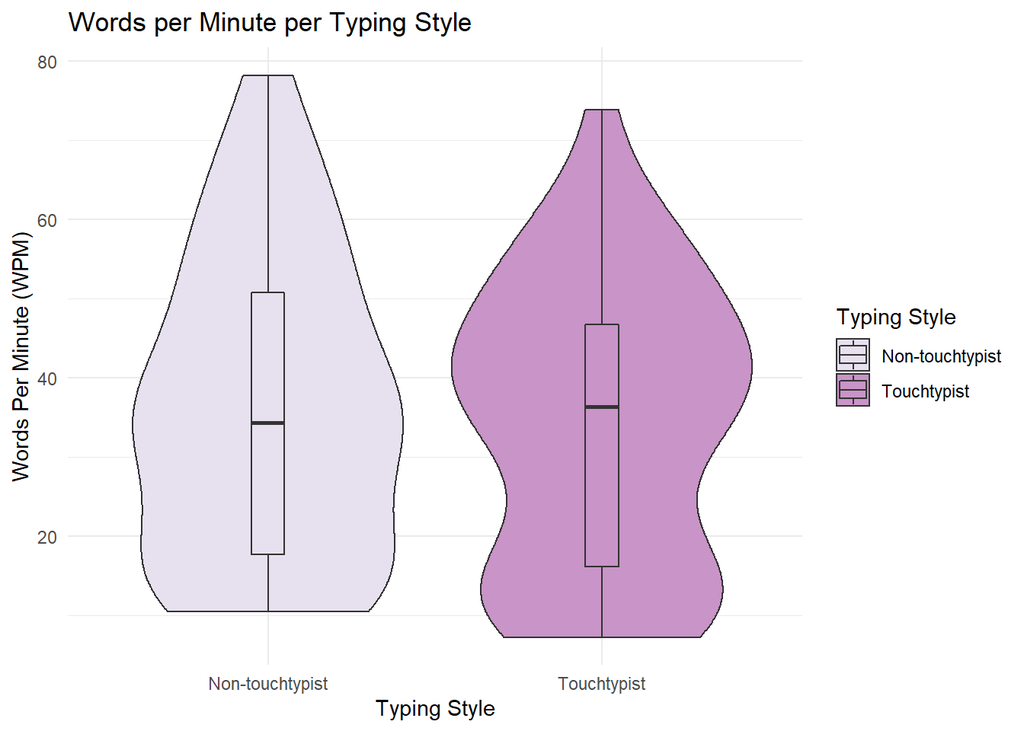

**Non-Parametric Statistics**

- Median: Nontouchtypist = 34.3066834 *wpms*, Touchtypist = 36.384337 *wpms*
- Interval: Nontouchtypist = (min= 10.4895105 *wpms*, max=78.2560089 *wpms*), Touchtypist = (min=7.2573329 *wpms*, max=73.8996559 *wpms*)
- Interquartile Range (IQR) : The `IQR` of Nontouchtypists = 33.150654 and Touchtypists = 30.5350213.

The differences in median, interval, and IQR is very small, further showing that there is not a significant difference in the results from Nontouchtypist and Touchtypist.

**Parametric Statistics**

- Mean: Non-touchtypist = 36.1797244 *wpms*, Touchtypist = 34.0888643 *wpms*
- Spread: Variance of Non-touchtypist = 356.6256903, Variance of Touchtypist = 321.8579526.
- Standard deviation: Non-touchtypist = 18.8845357, Touchtypist = 17.9404

All of the values above show that they conditions are very similar.

```r
# r function for skewness
by(data = data$wpm, INDICES = data$typing_style, FUN = skewness)
```

```
## data$typing_style: Non-touchtypist
## [1] 0.4017579
## ------------------------------------------------------------
## data$typing_style: Touchtypist
## [1] 0.04985883
```

#### **RQ2 - words per minute (wpm) by condition**

With RQ2 in mind we create the same plot again for *words per minute (wpm)* by the different *conditions*.

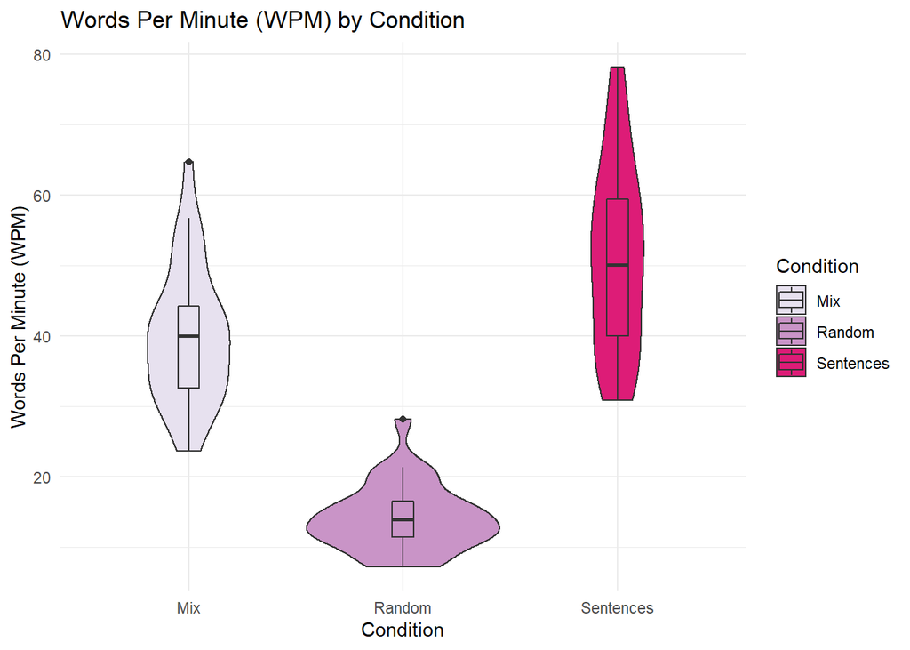

In contrast to the visualization before, in this case we immediately see that the violin and boxplots appear quite different with regards to the *conditions* and *word per minutes (wpm)*.

**Non-Parametric Statistics**

- Median: Mix = 40.0147473 *wpms*, Random = 13.9851792 *wpms*, Sentences = 50.1618746 *wpms*.
- Interval: Mix = (min=23.6483974 *wpms*, max=64.7029456 *wpms*), Random =(min=7.2573329 *wpms*, max=28.1579977 *wpms* ), and Sentences=(min=30.893995 *wpms*, max=78.2560089 *wpms*)
- IQR: Mix = 11.600442, Random = 5.1599867, Sentences = 19.4893757.

The `median`, `min`, `max`, as well as the `IQR` this time show significant differences that are also obvious in the visualizations. Upon these we can already make a statement about RQ2.

At this point we can already say that there are obvious differences between the *conditions*.

**Parametric Statistics**

- Mean:
  - For the Mix users have a `mean` of 39.985118 *wpms*, forRandom a `mean` of 14.1680566 *wpms* and forSentences has a `mean` of 51.0406225 *wpms*.
- Spread:
  - For the variance (`var`), Mix has a value of 93.8200508, Random has a value of 21.8960003 and Sentences has a value of 172.6837276.
  - Regarding the standard deviation, (`sd`) Mix accounts to 9.6860751, Random to 4.6793162 and Sentences to 13.1409181.